# Chick Embryo Elongation

Isabel Duarte

11 March, 2025

## Embryo Elongation

### Embryo elongation analysis | Formatting the input data

**Description** | Create table of differences for measurements of embryo lengths  
**Dependencies** | Input table with embryo measurement data  
**Notes** | Based on scripts “growth_analysis_step1.R” and “growth_analysis_step2.R”

```r
# Load libraries
library(tidyverse)
library(viridis)
library(ggridges)  # for ridge plot visualization
library(reshape2)  # for reshaping data
library(patchwork) # to combine plots

## Import dataset
filename <-  "data_embryo_elongation/input/CorrigidoFINAL_Grelha2_HH4-HH10_IsabelDuarte-alignedTimes_2019-07-01.csv"
raw.embryo.length <- read.table(file = filename, sep = ";", header = TRUE)

## Transpose the data so that the timepoints are the columns and the measurements per embryo are the rows
a <- seq(1, 416, 32)
z <- a + 31

list.per.embryo <- NULL
for (i in 1:13) {
  my.rows <- seq(a[i],z[i], by=1)
  list.per.embryo[[i]] <- t(raw.embryo.length[my.rows,3:11])
}

list.per.measure <- NULL
for (i in 1:9) {
  my.intermediate.list <- NULL
  for (ii in 1:13) {
    my.intermediate.list[[ii]] <- list.per.embryo[[ii]][i,]
  }
  list.per.measure[[i]] <- do.call(rbind, my.intermediate.list)
}

## Create data-frame with organized data
embryo_length <- as.data.frame(do.call(rbind, list.per.measure))

## Add column with embryo number and column with measure number
my.embryoNr <- rep(paste0("Emb", 1:13),9)
my.measure <- paste0("Med",rep(1:9, each=13))
embryo_length <- cbind(my.embryoNr, my.measure, embryo_length)

## Set the correct column names (timepoint)
my.colnames <- paste0("T", raw.embryo.length$TimePoint[1:32])
my.colnames <- c("EmbryoNr", "Measure", my.colnames)
colnames(embryo_length) <- my.colnames

## Inspect the formatted data table
head(embryo_length, n = c(10,13))
```

```
#>    EmbryoNr Measure  T-8  T-7  T-6  T-5  T-4  T-3  T-2  T-1   T0   T1   T2
#> 1      Emb1    Med1   NA   NA   NA   NA 2.69 2.78 2.86 3.03 3.36 3.64   NA
#> 2      Emb2    Med1   NA   NA   NA 1.63 1.75 1.91 2.09 2.26 2.50 2.70 2.85
#> 3      Emb3    Med1   NA   NA   NA   NA   NA   NA   NA 3.24 3.64 3.52 3.37
#> 4      Emb4    Med1   NA   NA 2.49 2.92 2.90 2.86 2.88 2.89 3.06 3.22 3.23
#> 5      Emb5    Med1 2.32 2.45 2.47 2.57 2.62 2.76 2.92 3.03 3.32 3.81 4.07
#> 6      Emb6    Med1   NA 2.61 2.72 2.65 2.76 2.80 2.80 2.91 3.07 3.25 3.43
#> 7      Emb7    Med1   NA   NA   NA   NA   NA   NA   NA   NA   NA   NA   NA
#> 8      Emb8    Med1   NA   NA   NA   NA   NA   NA 2.64 2.69 2.84 2.99 3.12
#> 9      Emb9    Med1   NA   NA   NA   NA   NA   NA   NA   NA   NA   NA   NA
#> 10    Emb10    Med1   NA   NA   NA   NA   NA   NA   NA   NA   NA   NA   NA
```

```r
## Cleanup
rm (my.intermediate.list, i, ii, a, z, list.per.embryo, list.per.measure,
    my.rows, my.embryoNr, my.measure, my.colnames)

## Save the file with the data formatted -> uncomment when changed
# write.table(embryo_length,
#             "input/input_formatted_embryo_length.csv",
#             sep = ";",
#             quote = FALSE,
#             row.names = FALSE,
#             col.names = TRUE)
```

### Embryo elongation analysis | Calculating embryo growth

```r
#### This code chunk was developed by Ramiro Magno (ramiro.magno@gmail.com)

#
# Calculation of the embryo growth (ratios of length between timepoints)
#

## embryo_length: two first columns only, i.e., annotation columns only.
embryo_length_annotation<- dplyr::select(embryo_length, c("EmbryoNr","Measure"))
## embryo_length without the first two columns (annotation)
embryo_length_data <- dplyr::select(embryo_length, -c("EmbryoNr","Measure"))
## Time combination pairs (matrix, each column is a pair)
time_combn <- combn(colnames(embryo_length_data), 2)

## Calculates the relative growth for two columns of df, indexed by the
## positions specified in the vector col.
relative_growth <- function(col, df) {1 - df[, col[1]]/df[, col[2]]}

## Calculate relative growth for each column pair (excluding self-self)
relative_growth_df <-
  apply(time_combn, 2, relative_growth, embryo_length_data) %>%
  as.data.frame()

## Add colnames following each combination pair.
colnames(relative_growth_df) <- paste0("1-",apply(time_combn, 2, paste, collapse = "/"))

## Inspect the results
head(relative_growth_df, n = c(10,7))
```

```
#>     1-T-8/T-7  1-T-8/T-6  1-T-8/T-5 1-T-8/T-4 1-T-8/T-3 1-T-8/T-2 1-T-8/T-1
#> 1          NA         NA         NA        NA        NA        NA        NA
#> 2          NA         NA         NA        NA        NA        NA        NA
#> 3          NA         NA         NA        NA        NA        NA        NA
#> 4          NA         NA         NA        NA        NA        NA        NA
#> 5  0.05306122 0.06072874 0.09727626 0.1145038 0.1594203 0.2054795 0.2343234
#> 6          NA         NA         NA        NA        NA        NA        NA
#> 7          NA         NA         NA        NA        NA        NA        NA
#> 8          NA         NA         NA        NA        NA        NA        NA
#> 9          NA         NA         NA        NA        NA        NA        NA
#> 10         NA         NA         NA        NA        NA        NA        NA
```

```r
## Write results to file -> uncomment when needed
# write.table(relative_growth_df,
#             "data_embryo_elongation/output/output_relative_growth.csv",
#             sep = ";", quote = FALSE, row.names = FALSE, col.names = TRUE)
```

### Embryo elongation analysis | Growth rate analysis

```r
## Calculates the GROWTH RATES between each pairwise combination of timepoints
## (Tfinal - Tinitial)

## Create matrix of combinations of timepoints to use as delta-time (denominator or rate calculation)
my_timepoints <- c(-8:23)
timepoint_combn_rates <- combn(my_timepoints, 2, simplify = FALSE) %>%
  lapply(rev)

## Combination pairs of columns to calculate numerator of rate (matrix, each column is a pair)
time_combn_rates <- combn(colnames(embryo_length_data), 2, simplify = FALSE) %>%
  lapply(rev)

## Function to calculate the growth rate
rate_growth <- function(col, dftime, dfmeasure) { (dfmeasure[,col[1]]-dfmeasure[,col[2]]) / (dftime[1]-dftime[2]) }

## Growth rate calculation
rate_growth_df <-
  purrr::map2(time_combn_rates,timepoint_combn_rates,rate_growth, embryo_length_data) %>% as.data.frame()

## Add colnames
colnames(rate_growth_df) <-
  purrr::map_chr(time_combn_rates, paste, collapse="_") %>% paste0("_by_dt")

## Add the two metadata columns
rate_growth_df <- cbind (embryo_length_annotation,rate_growth_df)

## Inspect the results
head(rate_growth_df, n=c(10,6))
```

```
#>    EmbryoNr Measure T-7_T-8_by_dt T-6_T-8_by_dt T-5_T-8_by_dt T-4_T-8_by_dt
#> 1      Emb1    Med1            NA            NA            NA            NA
#> 2      Emb2    Med1            NA            NA            NA            NA
#> 3      Emb3    Med1            NA            NA            NA            NA
#> 4      Emb4    Med1            NA            NA            NA            NA
#> 5      Emb5    Med1          0.13         0.075    0.08333333         0.075
#> 6      Emb6    Med1            NA            NA            NA            NA
#> 7      Emb7    Med1            NA            NA            NA            NA
#> 8      Emb8    Med1            NA            NA            NA            NA
#> 9      Emb9    Med1            NA            NA            NA            NA
#> 10    Emb10    Med1            NA            NA            NA            NA
```

```r
## Save results to file -> uncomment when needed
# write.table(rate_growth_df,
#             "data_embryo_elongation/output/output_rate_growth.csv",
#             sep = ";", quote = FALSE, row.names = FALSE, col.names = TRUE)

### NOTE: Create an excel file with the 2 output files in 2 separate sheets, to share with other lab members.
```

### Visualize the embryo length

**Dependencies** Input table with data (this file is the output from the previous chunks).

```r
## Vector with the HH stages ordered
my.hh.order <- c("HH4","HH5","HH6","HH7","HH8","HH9","HH10")

# Format dataset
raw.embryo.length %>%
  select(Embriao, Estadio, TimePoint, starts_with("Med")) %>%
  filter(!is.na(Estadio)) %>%
  mutate_at(vars(Estadio), funs(paste0("HH", .))) %>%
  mutate(Estadio = factor(Estadio, levels = my.hh.order)) -> clean.embryo.length

## Summary stats
clean.embryo.length %>%
  count(Embriao)
```

```
#>    Embriao  n
#> 1        1  6
#> 2        2 14
#> 3        3 25
#> 4        4 25
#> 5        5 28
#> 6        6 13
#> 7        7 20
#> 8        8 25
#> 9        9 11
#> 10      10  7
#> 11      11 24
#> 12      12 14
#> 13      13 16
```

```r
clean.embryo.length %>%
  count(Estadio)
```

```
#>   Estadio  n
#> 1     HH4 34
#> 2     HH5 63
#> 3     HH6 30
#> 4     HH7 41
#> 5     HH8 35
#> 6     HH9 22
#> 7    HH10  3
```

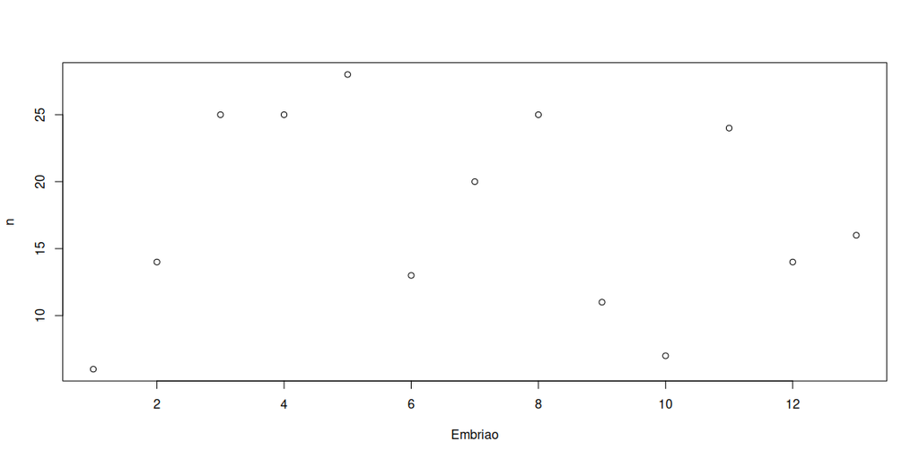

```r
## Look at data
clean.embryo.length %>%
  count(Embriao) %>%
  plot (.)
```

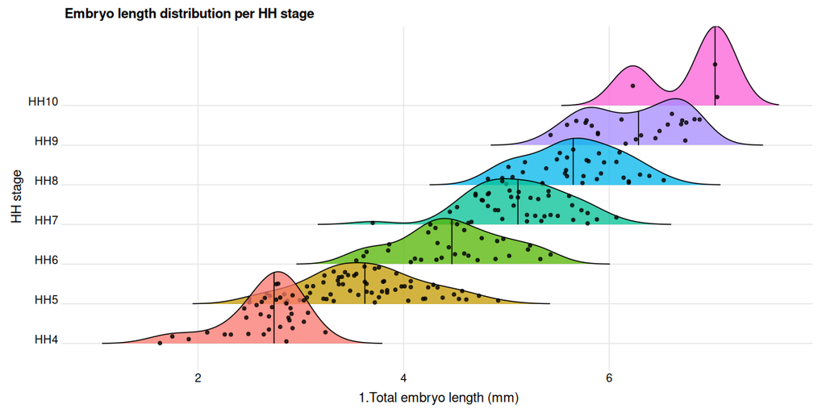

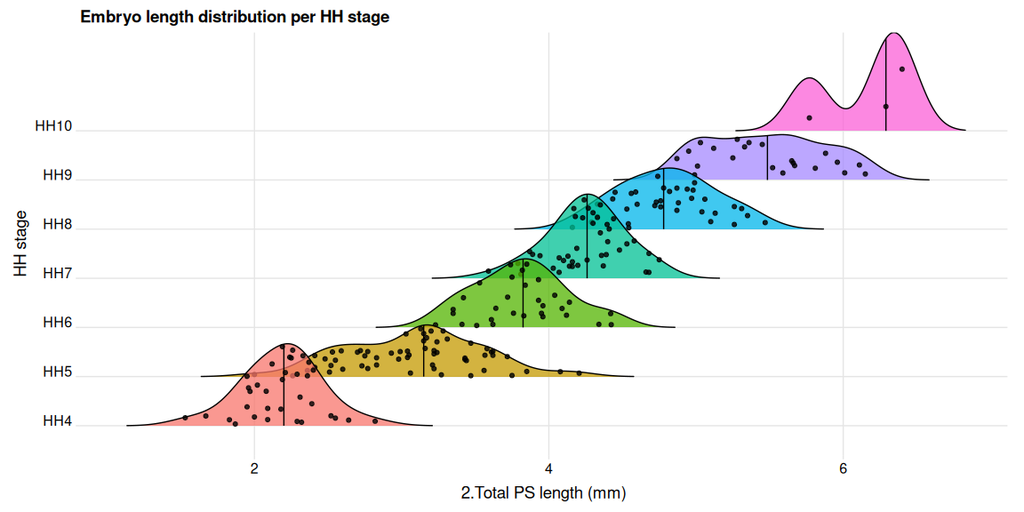

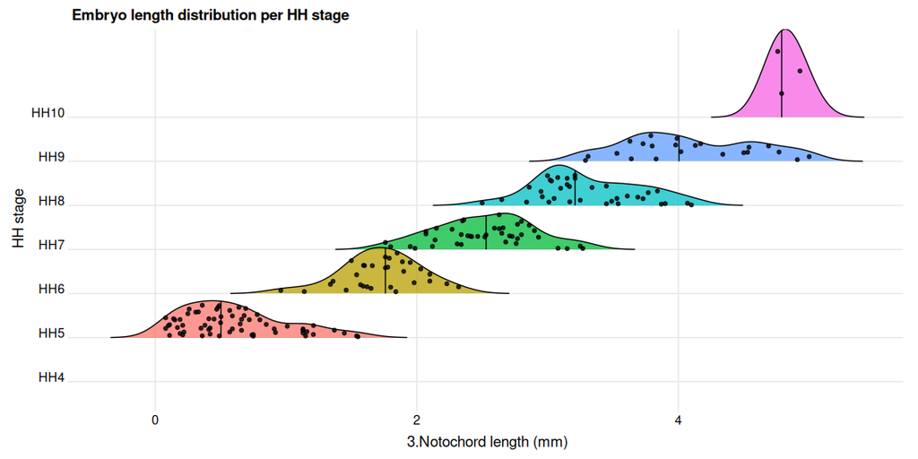

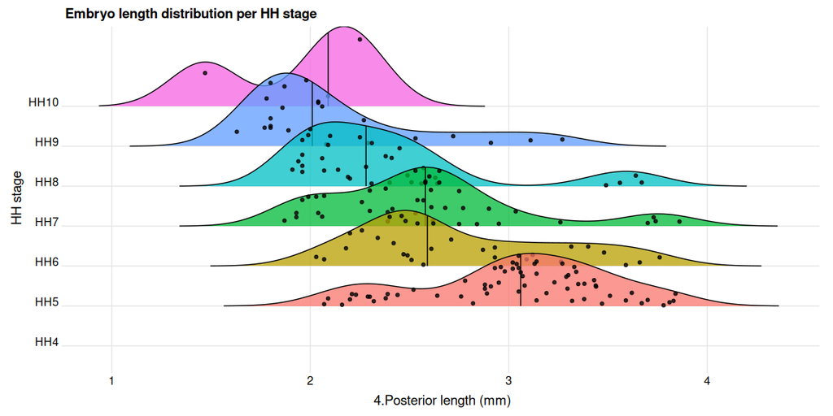

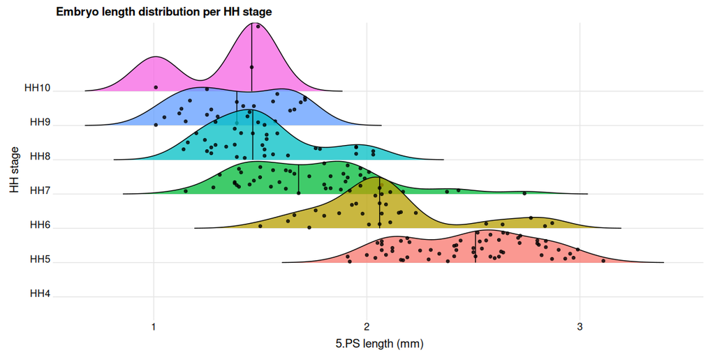

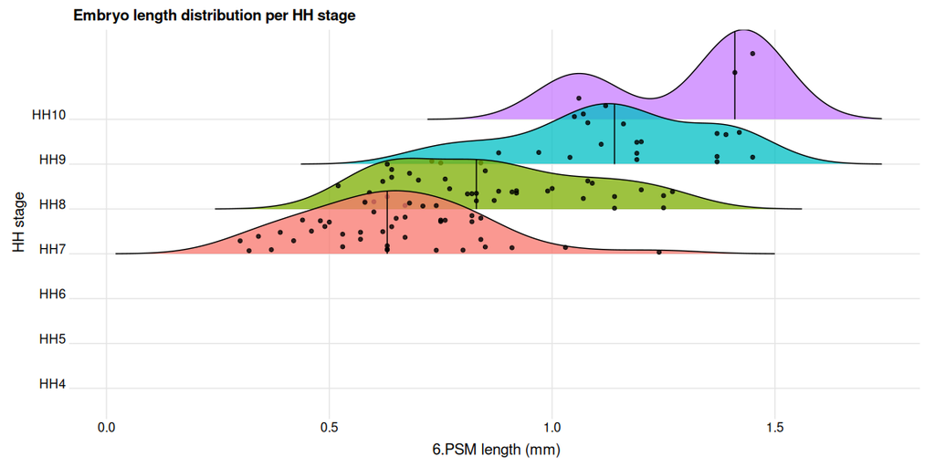

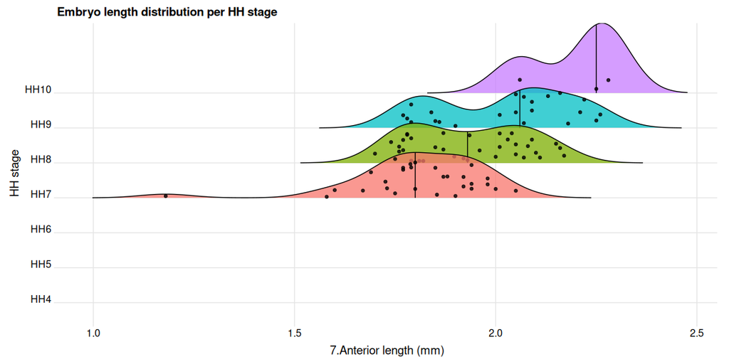

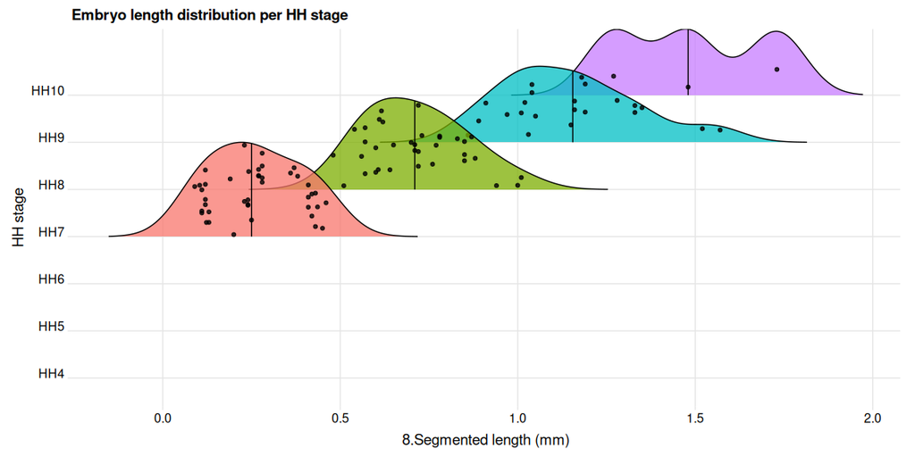

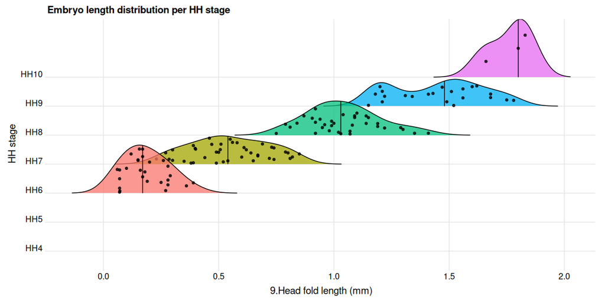

```r
## Ridge line plots for LENGTH (all 9 measures)
for (i in 1:9) {
  my.xlabs <- c("1.Total embryo length (mm)",
                "2.Total PS length (mm)",
                "3.Notochord length (mm)",
                "4.Posterior length (mm)",
                "5.PS length (mm)",
                "6.PSM length (mm)",
                "7.Anterior length (mm)",
                "8.Segmented length (mm)",
                "9.Head fold length (mm)")
  plot <-
    ggplot(clean.embryo.length, mapping=aes(x = clean.embryo.length[,i+3],
                                            y = Estadio, fill = Estadio)) +
    geom_density_ridges(alpha=0.75, rel_min_height = 0.001, scale = 2,
                        quantile_lines = TRUE, quantiles=2,
                        jittered_points = TRUE, position = "points_sina",
                        point_alpha = 0.8) +
    theme_ridges(grid = TRUE, center_axis_labels = TRUE)+
    theme(legend.position = "none") +
    #xlim(c(0, 7.1)) +
    #scale_x_continuous(breaks = seq(0, 8, 1)) +
    xlab(my.xlabs[i]) +
    ylab('HH stage') +
    ggtitle("Embryo length distribution per HH stage")

  print(plot)
}
```

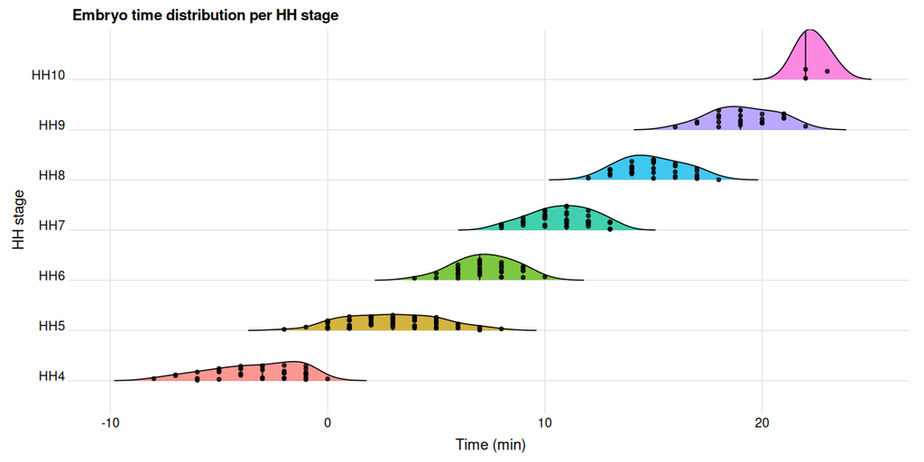

```r
## Ridge line plots for TIME
plot.time <-
    ggplot(clean.embryo.length, mapping=aes(x = TimePoint,
                                            y = Estadio, fill = Estadio)) +
    geom_density_ridges(alpha=0.75, rel_min_height = 0.001, scale = 1,
                        quantile_lines = TRUE, quantiles=2,
                        jittered_points = TRUE, position = "points_sina",
                        point_alpha = 0.8) +
    theme_ridges(grid = TRUE, center_axis_labels = TRUE)+
    theme(legend.position = "none") +
    #xlim(c(0, 7.1)) +
    #scale_x_continuous(breaks = seq(0, 8, 1)) +
    xlab("Time (min)") +
    ylab('HH stage') +
    ggtitle("Embryo time distribution per HH stage")

print(plot.time)
```

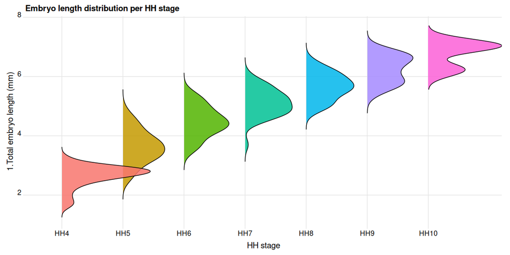

```r
#################################################
## Just one plot for testing VERTICAL ridgeline
ggplot(clean.embryo.length, mapping=aes(y = Med1, x = Estadio,
                                        width = ..density.., fill = Estadio)) +
  geom_vridgeline(stat="ydensity", trim=FALSE, alpha = 0.85, scale = 1, jittered_points = TRUE) +
  theme_ridges(grid = TRUE, center_axis_labels = TRUE)+
  theme(legend.position = "none") +
  #xlim(c(0, 7.1)) +
  #scale_x_continuous(breaks = seq(0, 8, 1)) +
  ylab("1.Total embryo length (mm)") +
  xlab('HH stage') +
  ggtitle("Embryo length distribution per HH stage")
```

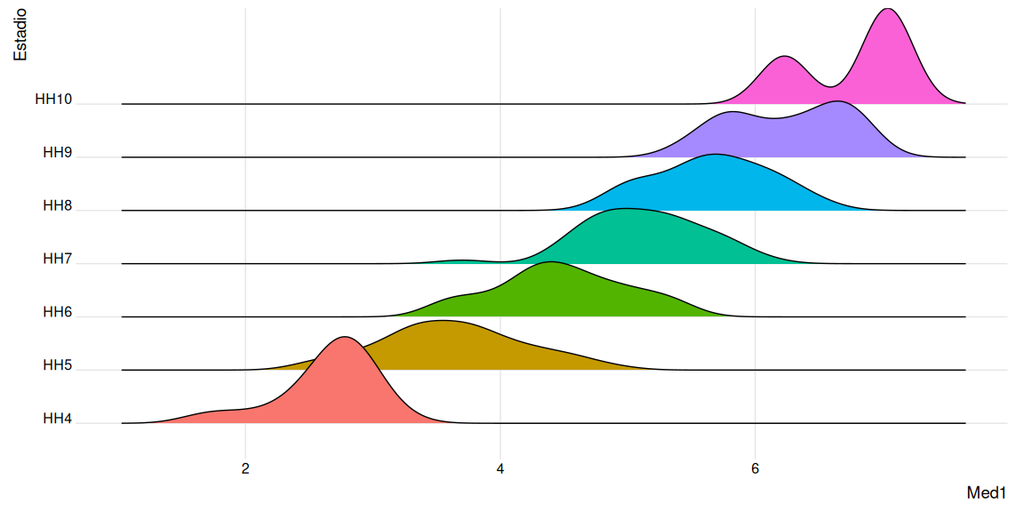

```r
## Just one plot for testing HORIZONTAL ridgeline
ggplot(clean.embryo.length, mapping=aes(x = Med1, y = Estadio, fill = Estadio)) +
  geom_density_ridges() +
  theme_ridges()+
  theme(legend.position = "none")
```

```r
################
#### EXTRAS ####
## Individual plots -> uncomment if needed
# ggplot(clean.embryo.length, mapping=aes(x = Med2, y = Estadio, fill = Estadio)) +
#   geom_density_ridges() +
#   theme_ridges()+
#   theme(legend.position = "none")
#
# ggplot(clean.embryo.length, mapping=aes(x = Med3, y = Estadio, fill = Estadio)) +
#   geom_density_ridges() +
#   theme_ridges()+
#   theme(legend.position = "none")
#
# ggplot(clean.embryo.length, mapping=aes(x = Med4, y = Estadio, fill = Estadio)) +
#   geom_density_ridges() +
#   theme_ridges()+
#   theme(legend.position = "none")


#################################################################
### Save the RData file -> uncomment when needed
# save.image(file = "data_embryo_elongation/embryo_elongation_analysis.RData")
```

### Calculate the overlap between measurement distributions

**Overview of the approach**

The idea is to calculate the integral of the minimum of the two density functions over the range where both have nonzero density. This provides a straightforward measure of similarity between two distributions, and therefore an intuitive way to quantify the overlap between the ridge plots (or kernel density estimates).

**Simple Overlap Calculation**

1. Estimate Kernel Density: Compute the density estimates for both distributions using the same grid of points.
2. Find the Intersection: At each grid point, take the minimum value of the two density functions.
3. Integrate the Intersection: Sum (or integrate) these minimum density values across the grid to obtain the overlap score.

Mathematically:

`Overlap = ∫ min(f1(x), f2(x)) dx`

where f1(x) and f2(x) are the density functions of the two distributions.

**Why This Works**

1. The approach is scale-invariant (not affected by total number of observations).
2. It gives an intuitive measure where 0 means no overlap and 1 means complete overlap (if densities are normalized).
3. It does not require complex statistics, just basic density estimation and summation.

#### Functions

```r
# Function to compute overlap between two distributions
calculate_overlap <- function(x1, x2, bw = "SJ", n = 512) {
  d1 <- density(x1, bw = bw, n = n)
  d2 <- density(x2, bw = bw, n = n)

  # Find common range where densities are nonzero
  lower_bound <- max(min(d1$x), min(d2$x))
  upper_bound <- min(max(d1$x), max(d2$x))

  # If there is no overlap, return 0
  if (lower_bound >= upper_bound) return(0)

  # Define the function for the minimum of two densities
  min_density_function <- function(x) {
    f1 <- approx(d1$x, d1$y, xout = x, rule = 2)$y
    f2 <- approx(d2$x, d2$y, xout = x, rule = 2)$y
    pmin(f1, f2)
  }

  # Compute the integral over the overlapping range
  overlap_value <- integrate(min_density_function, lower = lower_bound, upper = upper_bound)$value

  return(overlap_value)
}

# Function to compute pairwise overlaps and generate plots
calculate_pairwise_overlap <- function(data_list, my_name, bw = "SJ", n = 512) {

  names_list <- str_sort(names(data_list), numeric = TRUE)
  if (is.null(names_list)) names_list <- paste0("D", seq_along(data_list))

  n_datasets <- length(data_list)
  overlap_matrix <- matrix(0, nrow = n_datasets, ncol = n_datasets, dimnames = list(names_list, names_list))

  for (i in seq_len(n_datasets)) {
    for (j in seq_len(n_datasets)) {
      if (i <= j) {
        overlap_matrix[i, j] <- calculate_overlap(data_list[[i]], data_list[[j]], bw = bw, n = n)
        overlap_matrix[j, i] <- overlap_matrix[i, j] # Symmetric matrix
      }
    }
  }

  #
  # Plots
  #

  # More informative names for the measurements
  my_med_labs <- c(
    "Med1" = "Med1 | Total embryo length",
    "Med2" = "Med2 | Total PS length",
    "Med3" = "Med3 | Notochord length",
    "Med4" = "Med4 | Posterior length",
    "Med5" = "Med5 | PS length",
    "Med6" = "Med6 | PSM length",
    "Med7" = "Med7 | Anterior length",
    "Med8" = "Med8 | Segmented length",
    "Med9" = "Med9 | Head fold length"
  )

  # Convert matrix to long format for ggplot
  overlap_df <- melt(overlap_matrix)
  colnames(overlap_df) <- c("Distribution1", "Distribution2", "Overlap")

  # Heatmap plot
  heatmap_plot <-
    overlap_df |>
    filter(as.integer(Distribution2) <= as.integer(Distribution1)) |>
    ggplot(aes(x = Distribution1, y = Distribution2, fill = Overlap)) +
    geom_tile() +
    geom_text(aes(label = round(Overlap, 3)), color = "grey25", size = 5) +
    scale_fill_gradient(low = "white", high = "salmon") +
    theme_minimal() +
    labs(title = paste(my_name, "| Density Overlap"), fill = "Overlap") +
    theme(axis.text.x = element_text(angle = 45, hjust = 1))

  # Convert list to long format for ridge plot
  ridge_df <- do.call(rbind, lapply(names_list, function(name) {
    data.frame(Value = data_list[[name]], Distribution = name)
  }))

  # Convert Distribution to a factor with numerically ordered levels
  ridge_df$Distribution <- factor(ridge_df$Distribution, levels = names_list)

  # Ridge plot
  ridge_plot <- ggplot(ridge_df, aes(x = Value, y = Distribution, fill = Distribution)) +
    geom_density_ridges(alpha=0.75, rel_min_height = 0.001, scale = 1,
                        quantile_lines = TRUE, quantiles=2,
                        jittered_points = TRUE, position = "points_sina",
                        point_alpha = 0.7, point_size = 1, point_shape = 20) +
    theme_minimal() +
    #scale_fill_brewer(palette = "Set3") +
    labs(title = my_med_labs[my_name], x = "Length (mm)", y = "HH Stage") +
    theme(legend.position = "none")

  # Return both plots as a list
  # return(list(ridge_plot = ridge_plot, heatmap = heatmap_plot, overlap_matrix = overlap_matrix))
  return(list(ridge_plot = ridge_plot, heatmap = heatmap_plot))

}
```

#### Plots

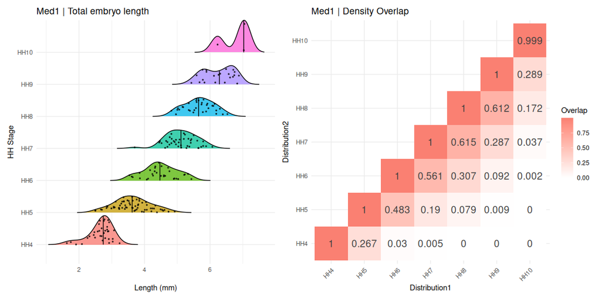

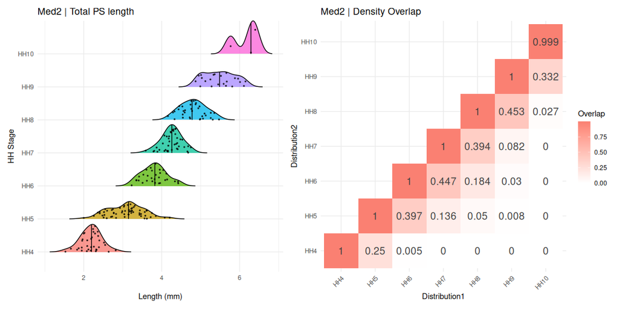

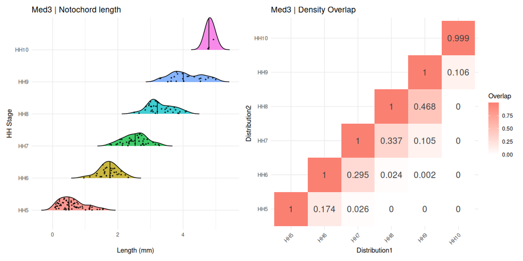

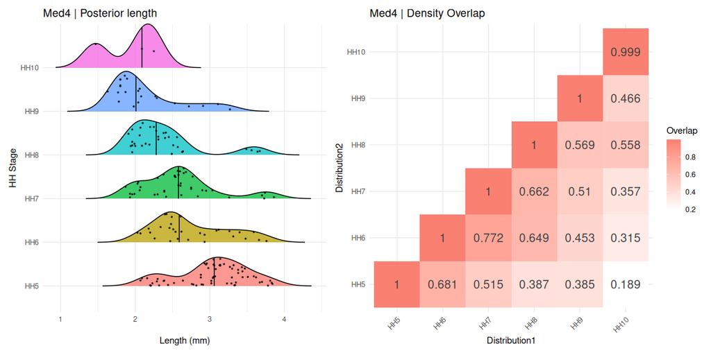

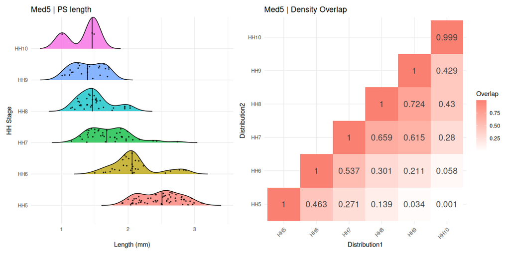

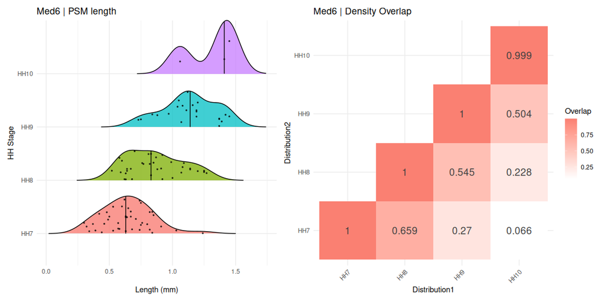

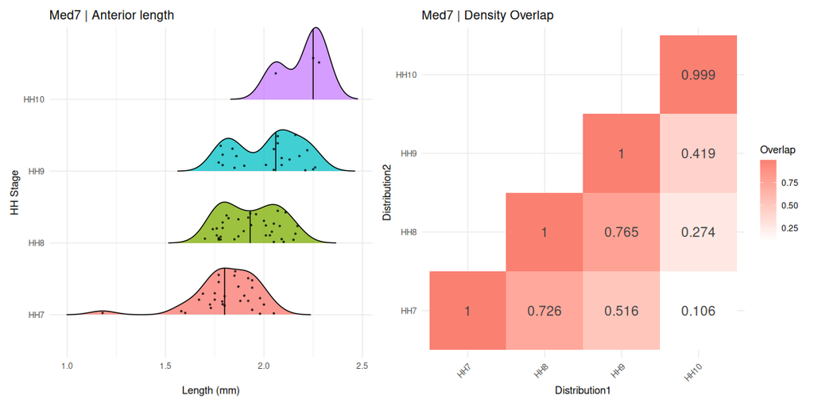

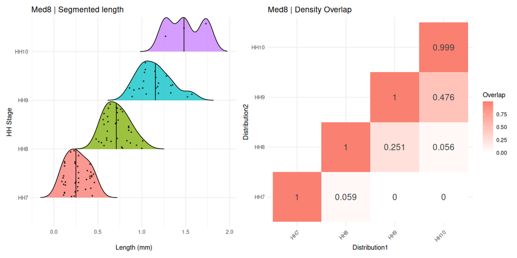

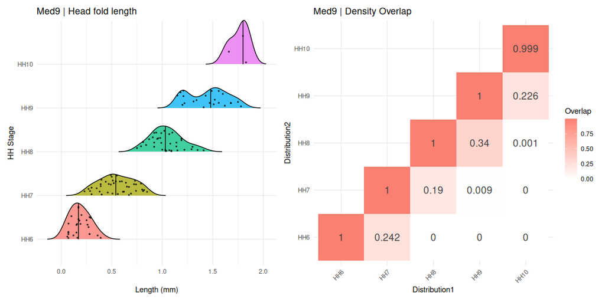

```r
# Format the input data as list
clean_embryo_length_list <- clean.embryo.length |>
  select(-TimePoint, -Embriao) |>
  pivot_longer(-Estadio, names_to = "Med", values_to = "Length") |>
  drop_na() |>
  group_by(Med, Estadio) |>
  summarise(Length = list(Length), .groups = "drop") |>
  nest(Length = c(Estadio, Length)) |>
  mutate(Length = map(Length, ~set_names(.x$Length, .x$Estadio))) |>
  deframe()


# Calculate the distribution overlap for all measurements
overlap_plots <- setNames(
  lapply(names(clean_embryo_length_list), function(name) {
    calculate_pairwise_overlap(clean_embryo_length_list[[name]], name)
  }),
  names(clean_embryo_length_list)
)

# Print the plots
combined_plots <- lapply(overlap_plots, function(sublist) {
  wrap_plots(sublist, ncol = 2)  # Combines the plots at this level
})

print(combined_plots)
```